# Individual1

Colin Willenborg

11/4/2020

## Question 1:

```r
accWeekDay <- acc %>%
  group_by(DAY_WEEK) %>%
  summarize(total = sum(DAY_WEEK, na.rm = TRUE))
str(accWeekDay)
```

```
## tibble [7 x 2] (S3: tbl_df/tbl/data.frame)
##  $ DAY_WEEK: int [1:7] 1 2 3 4 5 6 7
##  $ total   : int [1:7] 5360 8748 13041 17256 23105 32148 41111
```

The day with the most crashes is 7 or as the manual states Saturday.

## Question 2:

```r
accFatalities <- person %>%
  filter(INJ_SEV == 4)
str(accFatalities)
```

```
## 'data.frame':    37133 obs. of  68 variables:
##  $ STATE     : int  1 1 1 1 1 1 1 1 1 1 ...
##  $ ST_CASE   : int  10001 10002 10003 10004 10005 10006 10007 10008 10009 10011 ...
##  $ VE_FORMS  : int  1 1 3 1 1 2 2 1 1 2 ...
##  $ VEH_NO    : int  1 1 2 1 1 1 1 1 1 1 ...
##  $ PER_NO    : int  1 1 1 1 1 1 1 1 1 1 ...
##  $ STR_VEH   : int  0 0 0 0 0 0 0 0 0 0 ...
##  $ COUNTY    : int  73 89 101 73 13 49 73 3 87 87 ...
##  $ DAY       : int  19 14 31 1 1 6 11 11 11 15 ...
##  $ MONTH     : int  2 2 1 1 1 1 1 1 1 1 ...
##  $ HOUR      : int  23 14 20 16 20 18 17 16 14 4 ...
##  $ MINUTE    : int  35 59 31 55 0 40 57 50 30 35 ...
##  $ RUR_URB   : int  2 2 2 2 1 1 2 1 1 2 ...
##  $ FUNC_SYS  : int  1 1 1 4 1 1 1 1 1 1 ...
##  $ HARM_EV   : int  38 1 12 30 35 34 12 35 21 12 ...
```

[output cut: 54 more lines]

## Question 3:

```r
stateSafety <- person %>%
  select(STATE, COUNTY, INJ_SEV, MAKE) %>%
  filter(INJ_SEV == 4)
temp <- stateSafety %>%
  group_by(STATE, MAKE) %>%
  summarize(total = sum(INJ_SEV)) %>%
  arrange(desc(total))
temp <- temp[complete.cases(temp),]
temp <- temp %>%
  group_by(STATE) %>% slice(1)
```

## Question 4:

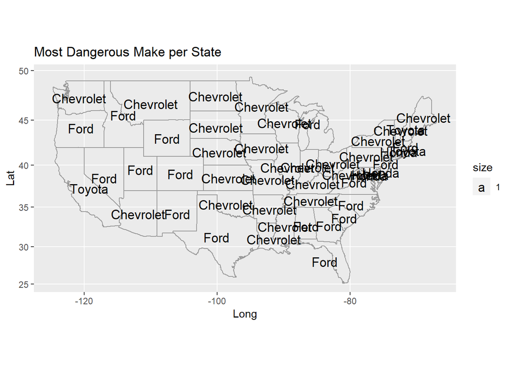

```r
states <- map_data("state")
makeCode <- read.csv("./makeCodes.csv")
geoLocation$`State Code` <- as.numeric(geoLocation$`State Code`)
states_temp <- inner_join(geoLocation, temp, by=c("State Code" = "STATE"))
states_temp <- states_temp %>%
  select('State Name', MAKE, total) %>%
  mutate('State Name' = tolower(states_temp$'State Name'))

states_temp <- states_temp[!duplicated(states_temp),]

states_join <- right_join(states_temp, states, by = c("State Name" = "region"))

states_join <- states_join[!duplicated(states_join$`State Name`, states_join$MAKE, states_join$total),]

temp3 <- left_join(states, states_join, by=c("region" = "State Name"))
cnames <- aggregate(cbind(long.x, lat.x) ~ region, data=temp3,
                    FUN=function(x)mean(range(x)))

temp4 <- left_join(states_join, cnames, by=c("State Name" = "region"))

temp4 <- inner_join(temp4, makeCode, by=c("MAKE" = "Codes"))

states %>% ggplot(aes(x=long, y=lat, group=group)) +
  geom_polygon(aes(group=group), fill = NA, colour = "grey60") + coord_map() +
  geom_text(data = temp4, aes(label = Make, x = long.x, y = lat.x, size=1))+ ylab("Lat") + xlab("Long") + ggtitle("Most Dangerous Make per State")
```

## Question 5:

```r
join_state_person <- inner_join(acc, person)
str(join_state_person)
```

```
## 'data.frame':    84921 obs. of  107 variables:
##  $ STATE     : int  1 1 1 1 1 1 1 1 1 1 ...
##  $ ST_CASE   : int  10001 10002 10003 10003 10003 10004 10005 10005 10006 10006 ...
##  $ VE_TOTAL  : int  1 1 3 3 3 1 1 1 2 2 ...
##  $ VE_FORMS  : int  1 1 3 3 3 1 1 1 2 2 ...
##  $ PVH_INVL  : int  0 0 0 0 0 0 0 0 0 0 ...
##  $ PEDS      : int  0 0 0 0 0 0 0 0 0 0 ...
##  $ PERNOTMVIT: int  0 0 0 0 0 0 0 0 0 0 ...
##  $ PERMVIT   : int  1 1 3 3 3 1 2 2 4 4 ...
##  $ PERSONS   : int  1 1 3 3 3 1 2 2 4 4 ...
##  $ COUNTY    : int  73 89 101 101 101 73 13 13 49 49 ...
##  $ CITY      : int  330 1730 2130 2130 2130 350 0 0 0 0 ...
##  $ DAY       : int  19 14 31 31 31 1 1 1 6 6 ...
##  $ MONTH     : int  2 2 1 1 1 1 1 1 1 1 ...
##  $ YEAR      : int  2017 2017 2017 2017 2017 2017 2017 2017 2017 2017 ...
```

[output cut: 86 more lines]

## Question 6:

```r
days_week <- readxl::read_xlsx("./days_week.xlsx")
accident_sex <- join_state_person %>%
  group_by(DAY_WEEK, HOUR, SEX) %>%
  summarize(total = sum(DAY_WEEK, HOUR, SEX)) %>%
  filter((SEX == 1 | SEX == 2) & HOUR != 99) %>%
  mutate(SEX = ifelse(SEX == 1, 'M', 'F'))
accident_sex <- left_join(accident_sex, days_week, by=c("DAY_WEEK" = "Code"))
accident_sex
```

```
## # A tibble: 336 x 5
## # Groups:   DAY_WEEK, HOUR [168]
##    DAY_WEEK  HOUR SEX   total Day_Week
##       <dbl> <int> <chr> <int> <chr>
##  1        1     0 M       976 Sunday
##  2        1     0 F       663 Sunday
##  3        1     1 M      1446 Sunday
##  4        1     1 F       800 Sunday
##  5        1     2 M      2140 Sunday
##  6        1     2 F      1190 Sunday
##  7        1     3 M      1880 Sunday
##  8        1     3 F       888 Sunday
##  9        1     4 M      1872 Sunday
## 10        1     4 F       553 Sunday
## # ... with 326 more rows
```

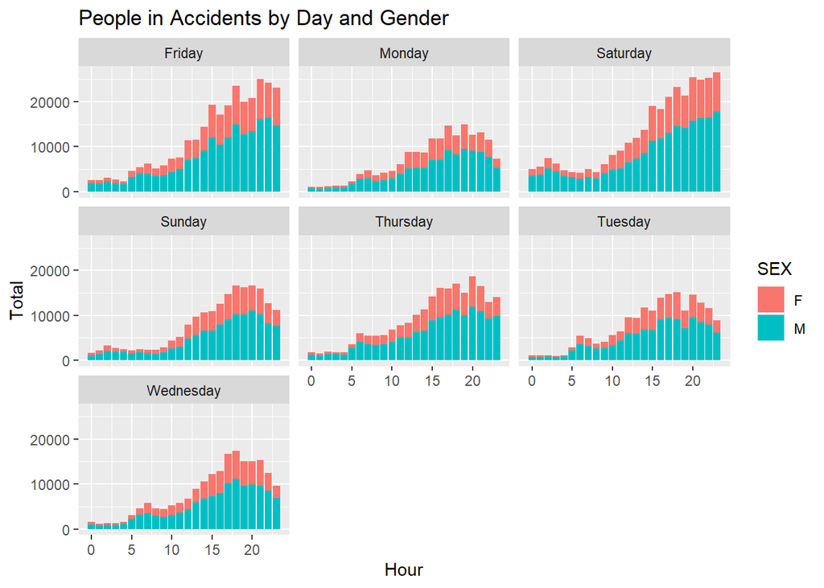

```r
accident_sex %>% ggplot(aes(x=HOUR, y = total, fill=SEX)) + geom_bar(stat="identity") + facet_wrap(~Day_Week) + ylab("Total") + xlab("Hour") + ggtitle("People in Accidents by Day and Gender")
```

This group of graphs shows that the most dangerous days are Friday and Saturday and on all days and all hours it is more men than women that are getting in fatal car accidents.

## Question 7:

```r
accidents_county <- join_state_person %>%
  group_by(STATE, COUNTY, INJ_SEV) %>%
  filter(INJ_SEV == 4) %>%
  summarize(total = sum(INJ_SEV))
```

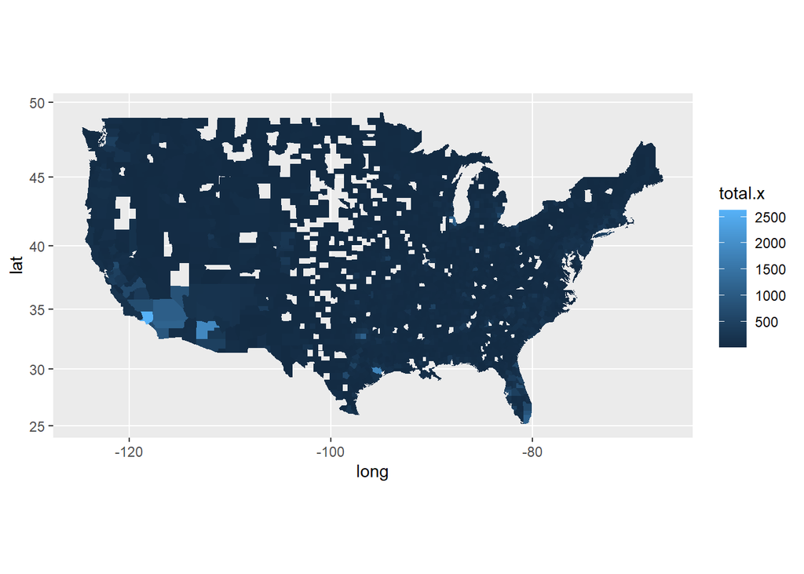

```r
county_map <- map_data("county")

county_code <- geoLocation %>%
  select('County Name', 'County Code', 'State Name', 'State Code') %>%
  mutate('County Name' = tolower(geoLocation$`County Name`)) %>%
  mutate('State Name' = tolower(geoLocation$`State Name`))

county_map <- right_join(county_map, county_code, by=c("region" = "State Name", "subregion" = "County Name"))

county_map <- county_map %>%
  mutate("County Code" = as.numeric(county_map$`County Code`)) %>%
  mutate("State Code" = as.numeric(county_map$`State Code`))

county_map <- inner_join(county_map, accidents_county, by=c("County Code" = "COUNTY", "State Code" = "STATE"))

county_map <- county_map %>%
  mutate(total.x = ifelse(is.na(total), 0, total))

county_map %>% ggplot(aes(x=long, y=lat, fill=total.x)) + geom_polygon(aes(group = group, fill=total.x)) + coord_map()
```

The graph shows that the more populated areas like Texas and California have the most car accidents per county.

## Question 8:

```r
weather <- acc %>%
  filter((MONTH == 06 & DAY >= 21) | MONTH == 8 | (MONTH == 9 & DAY < 23) | (MONTH == 12 & DAY > 20) | MONTH == 1 | MONTH == 2 | (MONTH == 3 & DAY == 7)) %>%
  mutate(Season = ifelse((MONTH == 06 & DAY >= 21) | MONTH == 8 | (MONTH == 9 & DAY < 23), 'Summer', 'Winter'))

weather %>% group_by(Season) %>%
  count(Season)
```

```
## # A tibble: 2 x 2
## # Groups:   Season [2]
##   Season     n
##   <chr>  <int>
## 1 Summer  6112
## 2 Winter  5966
```

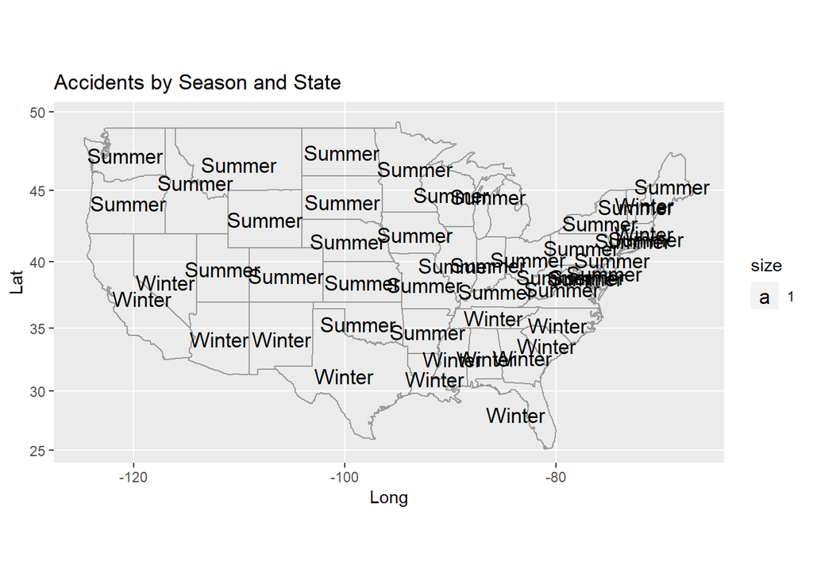

```r
weather_states <- weather %>%
  group_by(STATE, Season) %>%
  count(Season)

weather_states <- weather_states %>%
  group_by(STATE) %>%
  arrange(desc(n)) %>%
  slice(1)

Lat_long_list <- temp4 %>%
  select(`State Name`, long.x, lat.x)

weather_states <- left_join(weather_states, geoLocation, by=c("STATE" = "State Code"))

weather_states <- weather_states %>% group_by(`State Name`) %>%
  slice(1) %>%
  select(STATE, Season, n, `State Name`) %>%
  mutate(STATE = tolower(`State Name`))

weather_states <- inner_join(weather_states, Lat_long_list, by=c("STATE" = "State Name"))

states %>% ggplot(aes(x=long, y=lat)) +
  geom_polygon(aes(group=group), fill = NA, colour = "grey60") + coord_map() +
  geom_text(data = weather_states, aes(label = Season, x = long.x, y = lat.x, size=1)) + ylab("Lat") + xlab("Long") + ggtitle("Accidents by Season and State")
```

The maps and table show that the summer is the more dangerous month overall for the entire US. When we look at the graph though we see that the winter months are the most dangerous in the southern states and the summer is the most dangerous in most northern states. This could be for a multitude of reasons but one guess is that the summer in the northern states is similar to the weather the southern states experience and that is the time most people travel and take advantage of the good weather.